# p8105_hw5_rk3445

Rosie Kwon

2025-11-01

## Problem 1

A function that checks whether there are duplicate birthdays in the group

```r
duplicate_birthday = function(n) {
  birthdays = sample(1:365, n, replace = TRUE)

  repeated_bday = length(unique(birthdays)) < n

  repeated_bday
}
```

run this function 10000 times for each group size between 2 and 50.

```r
#For each group size, compute the probability that at least two people in the group will share a birthday by averaging across the 10000 simulation runs.
sim_results =
  expand_grid(
    bdays = 2:50,
    iter = 1:10000
  ) |>
  mutate(
    result = map_lgl(bdays, duplicate_birthday)
  ) |>
  group_by(
    bdays
  ) |>
  summarize(
    prob_repeat = mean(result)
  )
```

A plot showing the probability as a function of group size

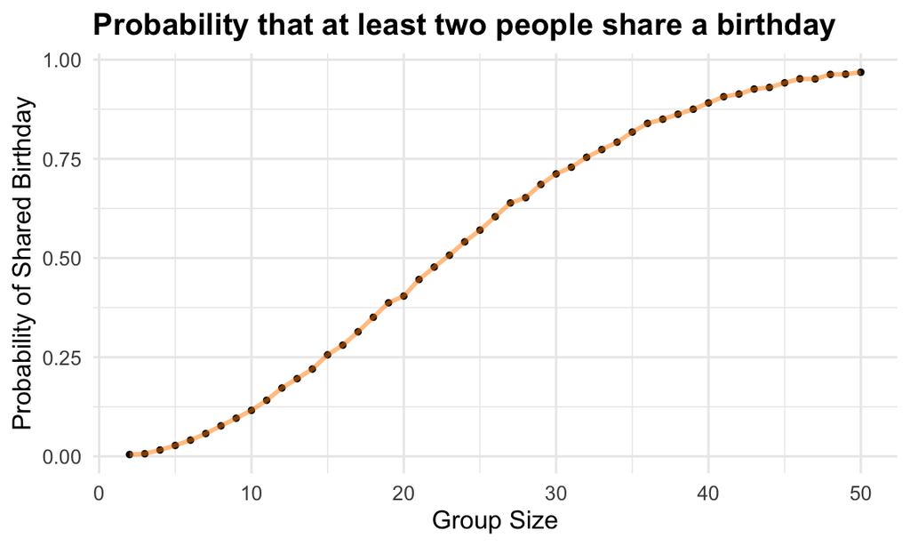

```r
sim_results |>
  ggplot(aes(x = bdays, y = prob_repeat)) +
  geom_point(size = 1) +
  geom_line(color = "darkorange", size = 1, alpha = 0.5) +
  labs(
    title = "Probability that at least two people share a birthday",
    x = "Group Size",
    y = "Probability of Shared Birthday"
  ) +
  theme_minimal(base_size = 12) +
  theme(
    plot.title = element_text(face = "bold")
  )
```

The plot shows the probability of at least two people sharing a birthday with group sizes ranging from 2 to 50. We observe that the probability is close to zero at small group sizes but increases rapidly between group sizes of 10 and 30. Beyond that, the slope of the curve begins to slow and after group size of 45 the probability approaches 1.0 , meaning that almost every group of more than 40 people will have at least two individuals sharing a birthday.

## Problem 2

Define simulation function

```r
sim_t_test = function(samp_size = 30, mu = 0, sigma = 5, alpha = 0.05){

  results =
    map(1:5000, ~ rnorm(n = samp_size, mean = mu, sd = sigma)) |>
    map(~ t.test(.x, mu = 0)) |>
    map_df(~ broom::tidy(.x)) |>
    select(estimate, p.value) |>
    mutate(reject_null = p.value < alpha)

  return(results)
}
```

Run simulation for true means from 0 to 6

```r
t_test_results =
  expand_grid(mu = 0:6) |>
  mutate(result = map(mu, ~ sim_t_test(mu = .x))) |>
  unnest()
```

**Make a plot showing the proportion of times the null was rejected (the power of the test) on the y axis and the true value of 𝜇 on the x axis. Describe the association between effect size and power.**

```r
power_results =
t_test_results |>
  group_by(mu) |>
  summarize(
    proportion = mean(reject_null)
  )
```

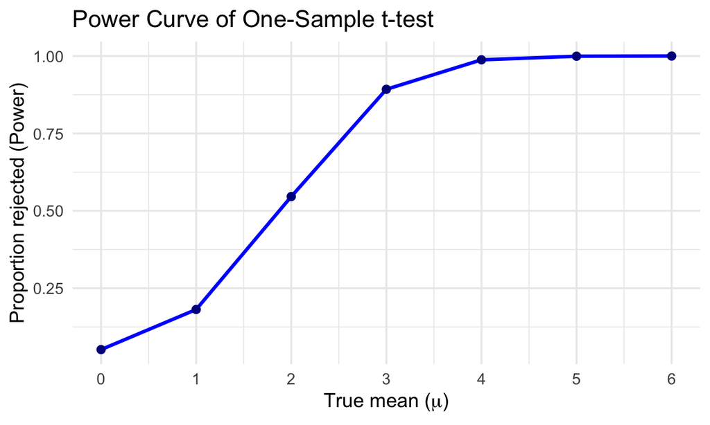

```r
power_results |>
  ggplot(aes(x = mu, y = proportion)) +
  geom_line(color = "blue", linewidth = 1) +
  geom_point(size = 2, color = "darkblue") +
  scale_x_continuous(breaks = 0:6) +
  labs(
    title = "Power Curve of One-Sample t-test",
    x = expression("True mean ("*mu*")"),
    y = "Proportion rejected (Power)"
  ) +
  theme_minimal(base_size = 12)
```

When μ = 0, the null hypothesis is true so that the test rejects the null about 5% of the time, matching with α = 0.05 significance level. As μ increases, the effect size grows, the test becomes more sensitive and more likely to reject the null hypothesis. Therefore, the power (probability of rejecting null hypothesis) increases approaching 1 as effect size increases.

**Make a plot showing the average estimate of 𝜇̂ on the y axis and the true value of 𝜇on the x axis. Make a second plot (or overlay on the first) the average estimate of 𝜇̂ only in samples for which the null was rejected on the y axis and the true value of 𝜇 on the x axis.**

Compute the averages

```r
avg_estimates =
  t_test_results |>
  group_by(mu) |>
  summarize(
    mean_est_all = mean(estimate),
    mean_est_reject = mean(estimate[reject_null]),
    .groups = "drop"
  )
```

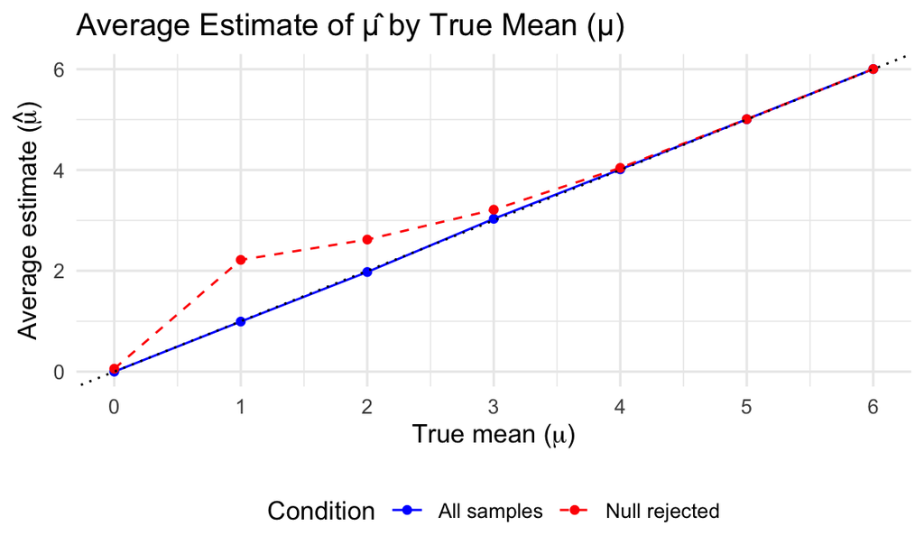

```r
avg_estimates |>
  ggplot(aes(x = mu)) +
  geom_line(aes(y = mean_est_all, color = "All samples")) +
  geom_point(aes(y = mean_est_all, color = "All samples"), size = 1.5) +
  geom_line(aes(y = mean_est_reject, color = "Null rejected"), linetype = "dashed") +
  geom_point(aes(y = mean_est_reject, color = "Null rejected"), size = 1.5) +
  scale_color_manual(values = c("All samples" = "blue", "Null rejected" = "red")) +
  geom_abline(intercept = 0, slope = 1, linetype = "dotted") +
  scale_x_continuous(breaks = 0:6) +
  labs(
    title = "Average Estimate of μ̂ by True Mean (μ)",
    x = expression("True mean ("*mu*")"),
    y = expression("Average estimate ("*hat(mu)*")"),
    color = "Condition"
  ) +
  theme_minimal(base_size = 12) +
  theme(legend.position = "bottom")
```

**Is the sample average of 𝜇̂ across tests for which the null is rejected approximately equal to the true value of 𝜇? Why or why not?**

The plot compares the average estimate of 𝜇̂ across all samples with the average estimate computed only from samples where the null hypothesis was rejected. The sample average estimates for all samples are close to the true mean 𝜇, showing that the estimator is unbiased. However, the sample average of 𝜇̂ for which the null is rejected is higher than the true mean especially for small effect sizes. From when 𝜇 is 5, the estimate value is approximately equal to the true mean. This is because we are conditioning on significance, so only samples with unusually large sample means (far from 0) tend to appear among the rejected cases.

# Problem 3

Load the dataset

```r
homicides =
  read_csv("data/homicide-data.csv") |>
  janitor::clean_names() |>
  mutate(
    city_state = paste(city , state, sep = ", "),
    solve_status = case_match(
      disposition,
      "Closed without arrest" ~ 1,
      "Open/No arrest" ~ 1,
      "Closed by arrest" ~ 0
    )
  )
```

The dataset from Washington Post homicide data contains information about murders in U.S. cities, including:

- `uid`: unique identifier for each case
- `victim_last`, `victim_first`: victim’s name
- `victim_age`, `victim_sex`, `victim_race`: demographics of victims
- `city`, `state`: location
- `disposition`: whether the case was solved or not

Dataset includes a total of 52179 observations and 14 variables.

```r
#Create a city_state variable (e.g. “Baltimore, MD”) and then summarize within cities to obtain the total number of homicides and the number of unsolved homicides (those for which the disposition is “Closed without arrest” or “Open/No arrest”).
homicides |>
  group_by(city) |>
  summarize(
    num_homicides = n(),
    unsolved = sum(solve_status, na.rm = TRUE)
  ) |>
  arrange(desc(num_homicides)) |>
  knitr::kable()
```

| city | num_homicides | unsolved |
| --- | --- | --- |
| Chicago | 5535 | 4073 |
| Philadelphia | 3037 | 1360 |
| Houston | 2942 | 1493 |
| Baltimore | 2827 | 1825 |
| Detroit | 2519 | 1482 |
| Los Angeles | 2257 | 1106 |
| St. Louis | 1677 | 905 |
| Dallas | 1567 | 754 |
| Memphis | 1514 | 483 |
| New Orleans | 1434 | 930 |
| Las Vegas | 1381 | 572 |
| Washington | 1345 | 589 |
| Indianapolis | 1322 | 594 |
| Kansas City | 1190 | 486 |
| Jacksonville | 1168 | 597 |
| Milwaukee | 1115 | 403 |
| Columbus | 1084 | 575 |
| Atlanta | 973 | 373 |
| Oakland | 947 | 508 |
| Phoenix | 914 | 504 |
| San Antonio | 833 | 357 |
| Birmingham | 800 | 347 |
| Nashville | 767 | 278 |
| Miami | 744 | 450 |
| Cincinnati | 694 | 309 |
| Charlotte | 687 | 206 |
| Oklahoma City | 672 | 326 |
| San Francisco | 663 | 336 |
| Pittsburgh | 631 | 337 |
| New York | 627 | 243 |
| Boston | 614 | 310 |
| Tulsa | 584 | 193 |
| Louisville | 576 | 261 |
| Fort Worth | 549 | 255 |
| Buffalo | 521 | 319 |
| Fresno | 487 | 169 |
| San Diego | 461 | 175 |
| Stockton | 444 | 266 |
| Richmond | 429 | 113 |
| Baton Rouge | 424 | 196 |
| Omaha | 409 | 169 |
| Albuquerque | 378 | 146 |
| Long Beach | 378 | 156 |
| Sacramento | 376 | 139 |
| Minneapolis | 366 | 187 |
| Denver | 312 | 169 |
| Durham | 276 | 101 |
| San Bernardino | 275 | 170 |
| Savannah | 246 | 115 |
| Tampa | 208 | 95 |

Estimate the proportion of homicides that are unsolved for the city of Baltimore, MD

```r
homicides |>
  filter(
    city_state == "Baltimore, MD"
  ) |>
  summarize(
    unsolved = sum(solve_status, na.rm = TRUE),
    total = n()
  ) |>
  with(prop.test(x = unsolved, n = total)) |>
  broom::tidy() |>
  select(estimate, conf.low, conf.high) |>
  knitr::kable()
```

| estimate | conf.low | conf.high |
| --- | --- | --- |
| 0.6455607 | 0.6275625 | 0.6631599 |

Proportion of unsolved homicides and the confidence interval for each cities.

```r
city_summary =
  homicides |>
  group_by(city) |>
  summarize(
    unsolved = sum(solve_status, na.rm = TRUE),
    total = n(),
    .groups = "drop"
  )


city_prop =
  city_summary |>
  mutate(
    test = map2(unsolved, total, ~ prop.test(x = .x, n = .y, correct = FALSE))
  ) |>
  mutate(tidy_test = map(test, broom::tidy)) |>
  select(city, tidy_test) |>
  unnest(tidy_test) |>
  select(city, estimate, conf.low, conf.high) |>
  arrange(estimate)

knitr::kable(city_prop)
```

| city | estimate | conf.low | conf.high |
| --- | --- | --- | --- |
| Richmond | 0.2634033 | 0.2239537 | 0.3070524 |
| Charlotte | 0.2998544 | 0.2667821 | 0.3351526 |
| Memphis | 0.3190225 | 0.2960277 | 0.3429333 |
| Tulsa | 0.3304795 | 0.2935459 | 0.3696286 |
| Fresno | 0.3470226 | 0.3060909 | 0.3903488 |
| Milwaukee | 0.3614350 | 0.3337565 | 0.3900649 |
| Nashville | 0.3624511 | 0.3291947 | 0.3970784 |
| Durham | 0.3659420 | 0.3113154 | 0.4242491 |
| Sacramento | 0.3696809 | 0.3224364 | 0.4195613 |
| San Diego | 0.3796095 | 0.3364772 | 0.4247317 |
| Atlanta | 0.3833505 | 0.3533160 | 0.4143023 |
| Albuquerque | 0.3862434 | 0.3385390 | 0.4362367 |
| New York | 0.3875598 | 0.3502203 | 0.4262687 |
| Kansas City | 0.4084034 | 0.3808140 | 0.4365822 |
| Long Beach | 0.4126984 | 0.3641886 | 0.4629648 |
| Omaha | 0.4132029 | 0.3665050 | 0.4615162 |
| Las Vegas | 0.4141926 | 0.3884862 | 0.4403751 |
| San Antonio | 0.4285714 | 0.3953688 | 0.4624298 |
| Birmingham | 0.4337500 | 0.3998052 | 0.4683280 |
| Washington | 0.4379182 | 0.4116177 | 0.4645723 |
| Cincinnati | 0.4452450 | 0.4086712 | 0.4824216 |
| Philadelphia | 0.4478103 | 0.4302018 | 0.4655507 |
| Indianapolis | 0.4493192 | 0.4226906 | 0.4762415 |
| Louisville | 0.4531250 | 0.4129165 | 0.4939546 |
| Tampa | 0.4567308 | 0.3904328 | 0.5245980 |
| Baton Rouge | 0.4622642 | 0.4153589 | 0.5098471 |
| Fort Worth | 0.4644809 | 0.4231532 | 0.5063022 |
| Savannah | 0.4674797 | 0.4061098 | 0.5298496 |
| Dallas | 0.4811742 | 0.4565119 | 0.5059287 |
| Oklahoma City | 0.4851190 | 0.4475242 | 0.5228831 |
| Los Angeles | 0.4900310 | 0.4694418 | 0.5106541 |
| Boston | 0.5048860 | 0.4654318 | 0.5442795 |
| San Francisco | 0.5067873 | 0.4688021 | 0.5446943 |
| Houston | 0.5074779 | 0.4894145 | 0.5255218 |
| Minneapolis | 0.5109290 | 0.4598697 | 0.5617612 |
| Jacksonville | 0.5111301 | 0.4824732 | 0.5397141 |
| Columbus | 0.5304428 | 0.5006780 | 0.5599926 |
| Pittsburgh | 0.5340729 | 0.4950623 | 0.5726711 |
| Oakland | 0.5364308 | 0.5045870 | 0.5679803 |
| St. Louis | 0.5396541 | 0.5157355 | 0.5633915 |
| Denver | 0.5416667 | 0.4862072 | 0.5961126 |
| Phoenix | 0.5514223 | 0.5190309 | 0.5833833 |
| Detroit | 0.5883287 | 0.5689899 | 0.6073985 |
| Stockton | 0.5990991 | 0.5528518 | 0.6436463 |
| Miami | 0.6048387 | 0.5692572 | 0.6393432 |
| Buffalo | 0.6122841 | 0.5697703 | 0.6531541 |
| San Bernardino | 0.6181818 | 0.5595067 | 0.6736007 |
| Baltimore | 0.6455607 | 0.6277411 | 0.6629852 |
| New Orleans | 0.6485356 | 0.6234581 | 0.6728194 |
| Chicago | 0.7358627 | 0.7240874 | 0.7473108 |

Create a plot that shows the estimates and CIs for each city

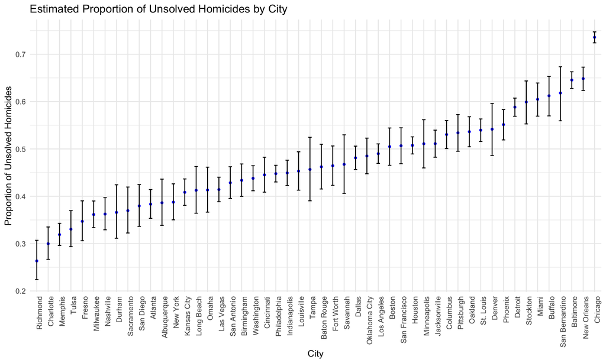

```r
city_prop |>
  mutate(city = factor(city, levels = city)) |>
  ggplot(aes(x = city, y = estimate)) +
  geom_point(color = "blue", size = 1) +
  geom_errorbar(aes(ymin = conf.low, ymax = conf.high), width = 0.3) +
  labs(
    x = "City",
    y = "Proportion of Unsolved Homicides",
    title = "Estimated Proportion of Unsolved Homicides by City"
  ) +
  theme_minimal() +
  theme(
    axis.text.x = element_text(angle = 90, hjust = 1, vjust = 1)
  )
```

The plot shows how large a share of homicides remain unsolved in major cities in the US. Richmond, Charlotte, and Memphis appear on the left with the lowest proportions while Chicago has the highest proportions (over 70%) indicating a much larger share of unsolved homicide cases in Chicago.